# Part I - Ford GoBike System Data Exploration

## Univariate Exploration

```python
    df.dtypes
```

```
duration_sec                 int64
start_time                  object
end_time                    object
start_station_id           float64
start_station_name          object
start_station_latitude     float64
start_station_longitude    float64
end_station_id             float64
end_station_name            object
end_station_latitude       float64
end_station_longitude      float64
bike_id                      int64
user_type                   object
member_birth_year          float64
member_gender               object
bike_share_for_all_trip     object
dtype: object
```

```python
    # Change the data types
    df['start_time'] = pd.to_datetime(df['start_time'])
    df['end_time'] = pd.to_datetime(df['end_time'])

    df['start_station_id'] = df['start_station_id'].astype('Int64')
    df['end_station_id'] = df['end_station_id'].astype('Int64')

    df['member_birth_year'] = df['member_birth_year'].astype('Int64')

    df['bike_id'] = df['bike_id'].astype('int')
    df['user_type'] = df['user_type'].astype('category')
    df['member_gender'] = df['member_gender'].astype('category')
    df['bike_share_for_all_trip'] = df['bike_share_for_all_trip'].astype('category')
```

```python
    df.describe()
```

|  | duration_sec | start_station_id | start_station_latitude | start_station_longitude | end_station_id | end_station_latitude | end_station_longitude | bike_id | member_birth_year |
| --- | --- | --- | --- | --- | --- | --- | --- | --- | --- |
| count | 183412.000000 | 183215.0 | 183412.000000 | 183412.000000 | 183215.0 | 183412.000000 | 183412.000000 | 183412.000000 | 175147.0 |
| mean | 726.078435 | 138.590427 | 37.771223 | -122.352664 | 136.249123 | 37.771427 | -122.352250 | 4472.906375 | 1984.806437 |
| std | 1794.389780 | 111.778864 | 0.099581 | 0.117097 | 111.515131 | 0.099490 | 0.116673 | 1664.383394 | 10.116689 |
| min | 61.000000 | 3.0 | 37.317298 | -122.453704 | 3.0 | 37.317298 | -122.453704 | 11.000000 | 1878.0 |
| 25% | 325.000000 | 47.0 | 37.770083 | -122.412408 | 44.0 | 37.770407 | -122.411726 | 3777.000000 | 1980.0 |
| 50% | 514.000000 | 104.0 | 37.780760 | -122.398285 | 100.0 | 37.781010 | -122.398279 | 4958.000000 | 1987.0 |
| 75% | 796.000000 | 239.0 | 37.797280 | -122.286533 | 235.0 | 37.797320 | -122.288045 | 5502.000000 | 1992.0 |
| max | 85444.000000 | 398.0 | 37.880222 | -121.874119 | 398.0 | 37.880222 | -121.874119 | 6645.000000 | 2001.0 |

```python
df = df[df['member_birth_year'] >= 1920]
#calculate age from 2019 because dataset was collected in 2019
df['age']=2019-df['member_birth_year']

# or we may drop records with (age >= 100)
#df = df[df['age'] <= 100]
```

```python
    df.isnull().sum()
```

```
duration_sec                 0
start_time                   0
end_time                     0
start_station_id           195
start_station_name         195
start_station_latitude       0
start_station_longitude      0
end_station_id             195
end_station_name           195
end_station_latitude         0
end_station_longitude        0
bike_id                      0
user_type                    0
member_birth_year            0
member_gender                0
bike_share_for_all_trip      0
age                          0
dtype: int64
```

```python
    df.shape
```

```
(175075, 17)
```

#### Questions:

```
1.What is the distribution of ride durations in the dataset, what duration approximately they ride most?
2.How is the distribution of user types (Subscribers, Customers) in individual rides made in a bike-sharing system covering the greater San Francisco Bay area?
```

#### Visualizations

Histogram to plot the distribution of Trip Durations

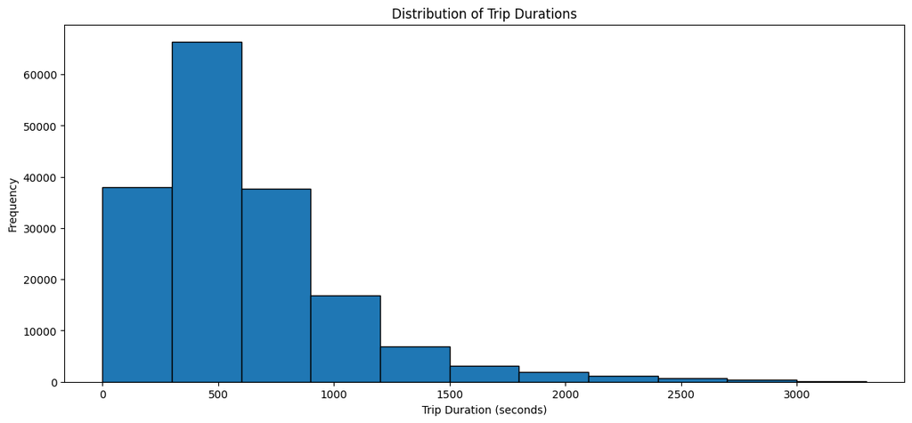

```python
    plt.figure(figsize = [14, 6])
    bins =np.arange(0,df['duration_sec'].quantile(0.99)+300,300)
    plt.xlabel('Trip Duration (seconds)')
    plt.ylabel('Frequency')
    plt.title('Distribution of Trip Durations')
    plt.hist(data = df.query('duration_sec<=duration_sec.quantile(0.99)'), x = 'duration_sec', bins = bins,edgecolor='black');
    plt.show()
```

to visualize the number of subscribers and customers with bar chart.

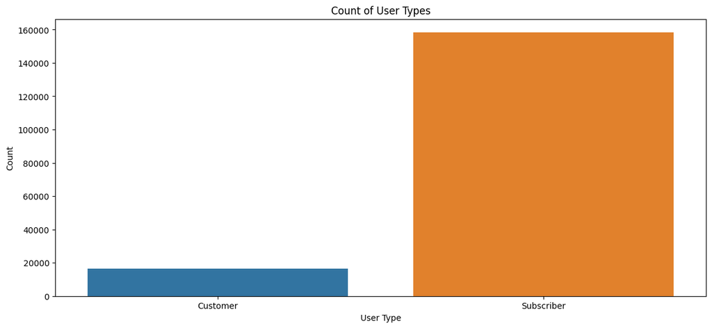

```python
    plt.figure(figsize=(14,6))
    sns.countplot(x='user_type', data=df)

    plt.xlabel('User Type')
    plt.ylabel('Count')
    plt.title('Count of User Types')

    plt.show()
```

#### Observations:

1. The histogram shows that most trips are less than 1000 seconds long(almost 17 minuites).
2. The count plot shows that most users in the dataset are Subscribers, with far fewer Customers. This suggests that the bike-sharing system is mostly used by subscribers, who might use it more regularly than customers who use it occasionally.

#### Of the features you investigated, were there any unusual distributions? Did you perform any operations on the data to tidy, adjust, or change the form of the data? If so, why did you do this?

Yes! we needed to change the data types to most suitable.

## Bivariate Exploration

#### Visualizations

1. Box plot to see relationship between trip distance and hour of the day.

```python
def haversine(lat1, lon1, lat2, lon2):
    """
    A function to calculate the distance traveled (in km)
    from one point two another using the haversine formula
    each point has latitude and longitude
    Parameters:
    lat1: starting latitude position for first point
    lon1: starting longitude position for first point
    lat2: starting latitude position for second point
    lon2: starting longitude position for first point

    Return:
     distance between the two points (in km)
    """
    R = 6371  # Radius of the Earth in km
    lat1, lon1, lat2, lon2 = map(np.radians, [lat1, lon1, lat2, lon2])
    dlat = lat2 - lat1
    dlon = lon2 - lon1
    a = np.sin(dlat / 2) ** 2 + np.cos(lat1) * np.cos(lat2) * np.sin(dlon / 2) ** 2
    c = 2 * np.arcsin(np.sqrt(a))
    return R * c
```

```python
df['distance_km'] = haversine(df['start_station_latitude'], df['start_station_longitude'],
                              df['end_station_latitude'], df['end_station_longitude'])
```

```python
    #convert 'start_time' to datetime and explicit hour
    df['start_time'] = pd.to_datetime(df['start_time'])
    df['hour']= df['start_time'].dt.hour
```

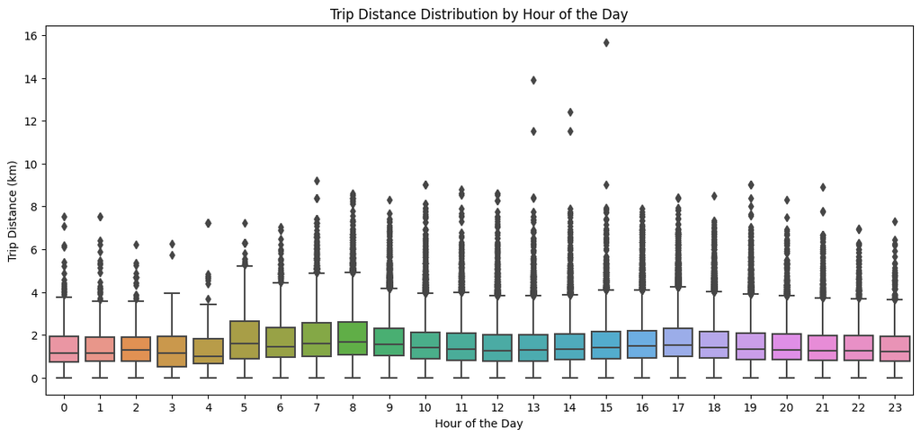

```python
    plt.figure(figsize=(14, 6))
    sns.boxplot(x='hour', y='distance_km', data=df.query('duration_sec<=duration_sec.quantile(0.99)'))
    plt.xlabel('Hour of the Day')
    plt.ylabel('Trip Distance (km)')
    plt.title('Trip Distance Distribution by Hour of the Day')
    plt.show()
```

another line plot to see relationship between trip distance and hour of the day.

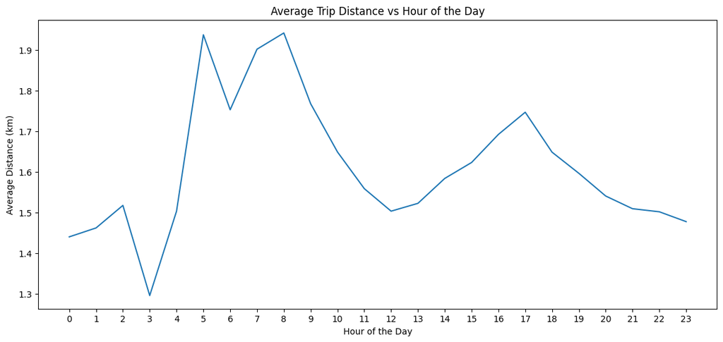

```python
    #calculate average distance per hour
    avg_distance_per_hour =df.groupby('hour')['distance_km'].mean().reset_index()

    plt.figure(figsize =(14, 6))
    sns.lineplot(x='hour', y='distance_km',data=avg_distance_per_hour)
    plt.xlabel('Hour of the Day')
    plt.ylabel('Average Distance (km)')
    plt.title('Average Trip Distance vs Hour of the Day')
    plt.xticks(range(0, 24))
    plt.show()
```

2. Scatterplot toshow how trip duration varies between different ages(birth years)

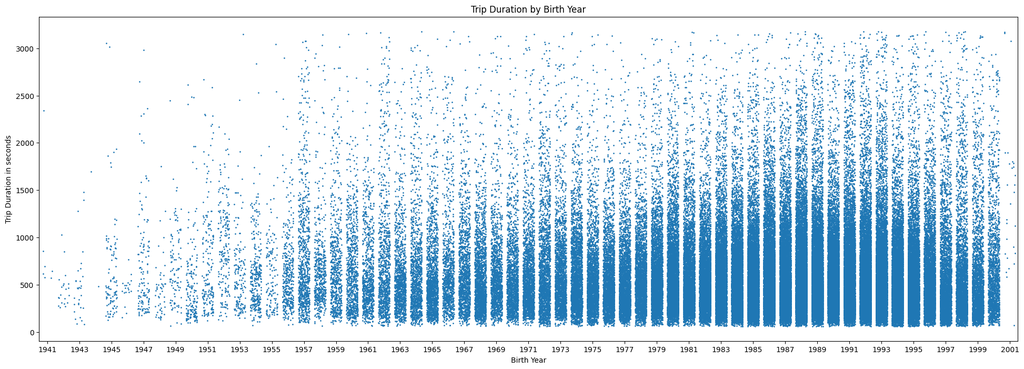

```python
    # drop rows with null values, query to drop outliers.
    cleaned_df = df[['member_birth_year', 'duration_sec']].dropna().query('member_birth_year>=1940 and duration_sec<=duration_sec.quantile(0.99)').copy()
    cleaned_df['member_birth_year']=cleaned_df['member_birth_year'].astype(int)
    plt.figure(figsize=[24, 8])

    sns.stripplot(data=cleaned_df,x='member_birth_year',y='duration_sec', size=2, jitter= 0.35)
    plt.xlabel('Birth Year')
    plt.ylabel('Trip Duration in seconds')
    plt.title('Trip Duration by Birth Year')
    # get current tick positions and labels
    pos, lab=plt.xticks()
    plt.xticks(pos[::2],lab[::2])
    plt.show()
```